# Logistic Regression (week3)

*This week we did data wrangling on two new data sets retrieved from the UCI Machine Learning Repository. The data are from two identical questionaires related to secondary school student alcohol comsumption in Portugal.* *We then perform analysis on the combined dataset*

#### Data set information: https://archive.ics.uci.edu/ml/datasets/STUDENT+ALCOHOL+CONSUMPTION

*P. Cortez and A. Silva. Using Data Mining to Predict Secondary School Student Performance. In A. Brito and J. Teixeira Eds., Proceedings of 5th FUture BUsiness TEChnology Conference (FUBUTEC 2008) pp. 5-12, Porto, Portugal, April, 2008, EUROSIS, ISBN 978-9077381-39-7.*

## 1. Data wrangling

*you can see it in my github:* https://github.com/tzsu/IODS-project/blob/master/data/create_alc.R

## 2. Analysis

### 1. Take a look at our new dataset

#### The following adjustments have been made:

- to The variables not used for joining the two data have been combined by averaging (including the grade variables)
- **alc_use** is the average of **Dalc** and **Walc**
- **high_use** is **TRUE** if alc_use is higher than 2 and FALSE otherwise. #### Some variables are numerical and some are not.

```
## Observations: 382
## Variables: 35
## $ school     <fctr> GP, GP, GP, GP, GP, GP, GP, GP, GP, GP, GP, GP, GP...
## $ sex        <fctr> F, F, F, F, F, M, M, F, M, M, F, F, M, M, M, F, F,...
## $ age        <int> 18, 17, 15, 15, 16, 16, 16, 17, 15, 15, 15, 15, 15,...
## $ address    <fctr> U, U, U, U, U, U, U, U, U, U, U, U, U, U, U, U, U,...
## $ famsize    <fctr> GT3, GT3, LE3, GT3, GT3, LE3, LE3, GT3, LE3, GT3, ...
## $ Pstatus    <fctr> A, T, T, T, T, T, T, A, A, T, T, T, T, T, A, T, T,...
## $ Medu       <int> 4, 1, 1, 4, 3, 4, 2, 4, 3, 3, 4, 2, 4, 4, 2, 4, 4, ...
## $ Fedu       <int> 4, 1, 1, 2, 3, 3, 2, 4, 2, 4, 4, 1, 4, 3, 2, 4, 4, ...
## $ Mjob       <fctr> at_home, at_home, at_home, health, other, services...
## $ Fjob       <fctr> teacher, other, other, services, other, other, oth...
## $ reason     <fctr> course, course, other, home, home, reputation, hom...
## $ nursery    <fctr> yes, no, yes, yes, yes, yes, yes, yes, yes, yes, y...
## $ internet   <fctr> no, yes, yes, yes, no, yes, yes, no, yes, yes, yes...
```

[output cut: 22 more lines]

### 2. Explore relationships between alcohol consumption and other variables

#### Here I have chosen 4 variables and with each of them, the following are my hypotheses based on personal experience. I am eager to know if my assumptions are true or not.

- Students who have better grades in the final drink less alcohol. (**G3**)
- Students who have more school absences drinks more. (**absences**)
- Students with more freetimes will consume more alcohol.(**freetime**)
- Those who are in a relationship will drink more. (**romantic**)

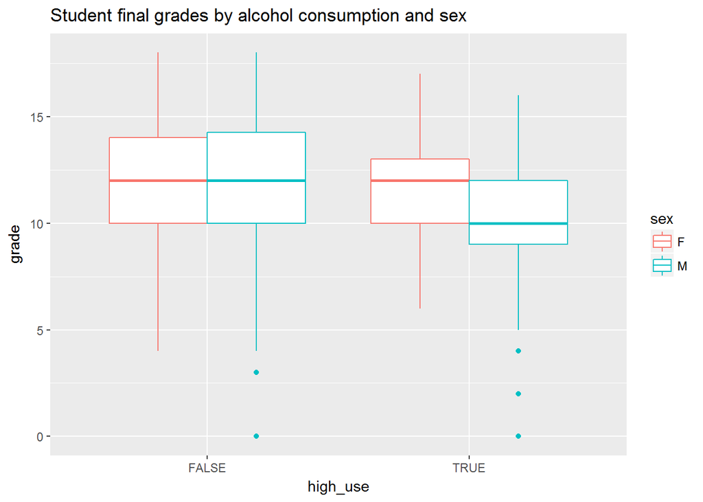

```r
# initialize a plot of high_use and G3
g1 <- ggplot(alc, aes(x = high_use, y = G3, col=sex)) + geom_boxplot() + ylab('final grade') + xlab('high_use')
# define the plot as a boxplot and draw it
g1 + geom_boxplot() + ylab("grade")+ ggtitle("Student final grades by alcohol consumption and sex")
```

#### Graph 1 does not seem to support my assumption perfectly. Grade and alcohol consumption are not correlated within the girls group, however, boys who drink more tend to have poorer grades.

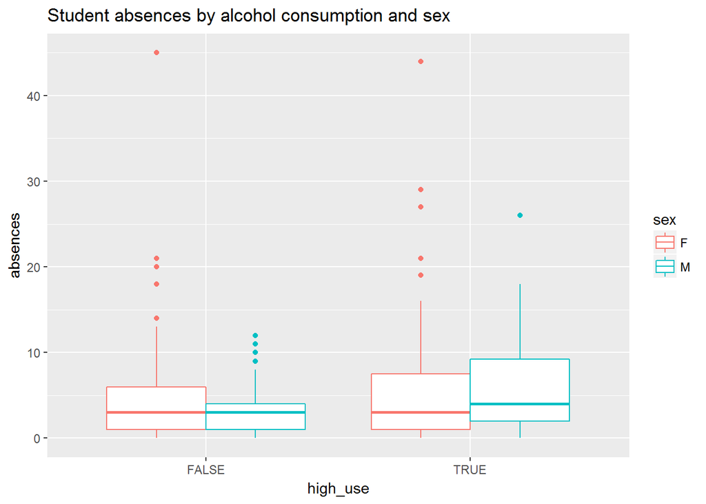

```r
# initialise a plot of high_use and absences
g2 <- ggplot(alc, aes(x= high_use, y = absences, col = sex))
# define the plot as a boxplot and draw it
g2 +geom_boxplot() + ggtitle("Student absences by alcohol consumption and sex")
```

#### Graph 2 seems to support my assumption that students who were absence from school more times will drink more.

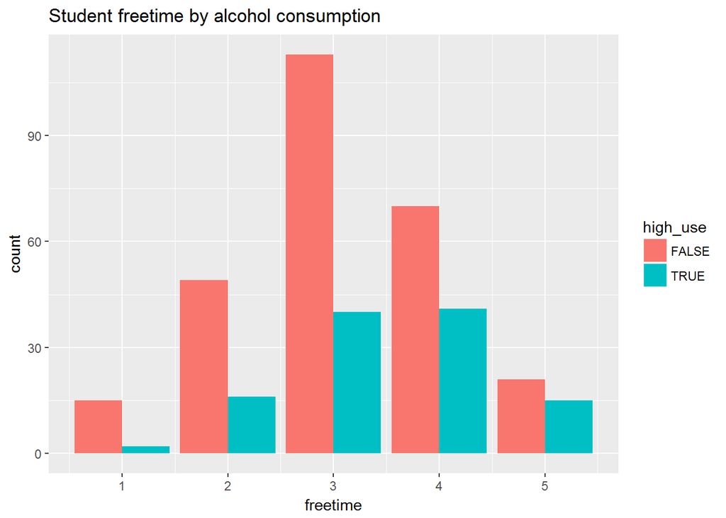

#### Graph 3 (although this graph may be hard to read), seems to support my hypothesis. There is a higher percentage of high_use when there is more freetime.

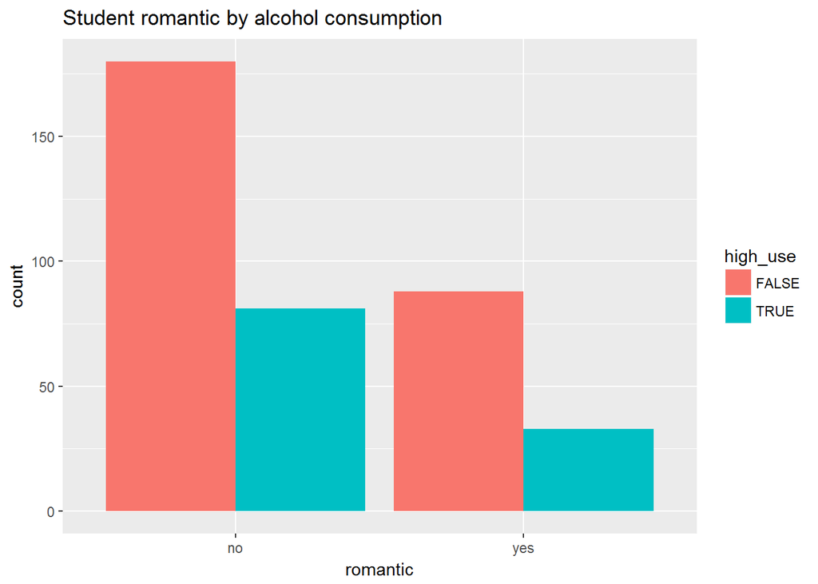

#### Graph 4 does not support my hypothesis. It even looks like the opposite of my assumption. There is a bigger percentage of “high_use” within the people who is not in a relationship.

### 3. Logistic regression

```
##
## Call:
## glm(formula = high_use ~ G3 + absences + freetime + romantic,
##     family = "binomial", data = alc)
##
## Deviance Residuals:
##     Min       1Q   Median       3Q      Max
## -1.9530  -0.8385  -0.6665   1.1801   1.9643
##
## Coefficients:
##             Estimate Std. Error z value Pr(>|z|)
## (Intercept) -1.51913    0.60984  -2.491  0.01274 *
## G3          -0.07804    0.03593  -2.172  0.02985 *
## absences     0.09021    0.02273   3.969 7.22e-05 ***
## freetime     0.37457    0.12303   3.044  0.00233 **
## romanticyes -0.38846    0.26103  -1.488  0.13670
## ---
## Signif. codes:  0 '***' 0.001 '**' 0.01 '*' 0.05 '.' 0.1 ' ' 1
##
## (Dispersion parameter for binomial family taken to be 1)
##
##     Null deviance: 465.68  on 381  degrees of freedom
## Residual deviance: 431.27  on 377  degrees of freedom
## AIC: 441.27
##
## Number of Fisher Scoring iterations: 4
```

#### Now I take out the variables grade and romantic, and fit the model again

```
##
## Call:
## glm(formula = high_use ~ absences + freetime, family = "binomial",
##     data = alc)
##
## Deviance Residuals:
##     Min       1Q   Median       3Q      Max
## -2.0492  -0.8434  -0.6919   1.1776   1.9269
##
## Coefficients:
##             Estimate Std. Error z value Pr(>|z|)
## (Intercept) -2.51574    0.44500  -5.653 1.57e-08 ***
## absences     0.09139    0.02276   4.015 5.94e-05 ***
## freetime     0.37222    0.12176   3.057  0.00223 **
## ---
## Signif. codes:  0 '***' 0.001 '**' 0.01 '*' 0.05 '.' 0.1 ' ' 1
##
## (Dispersion parameter for binomial family taken to be 1)
##
##     Null deviance: 465.68  on 381  degrees of freedom
## Residual deviance: 437.70  on 379  degrees of freedom
## AIC: 443.7
##
## Number of Fisher Scoring iterations: 4
```

### 4. Predictions

```
##         prediction
## high_use FALSE TRUE
##    FALSE   258   10
##    TRUE     96   18
```

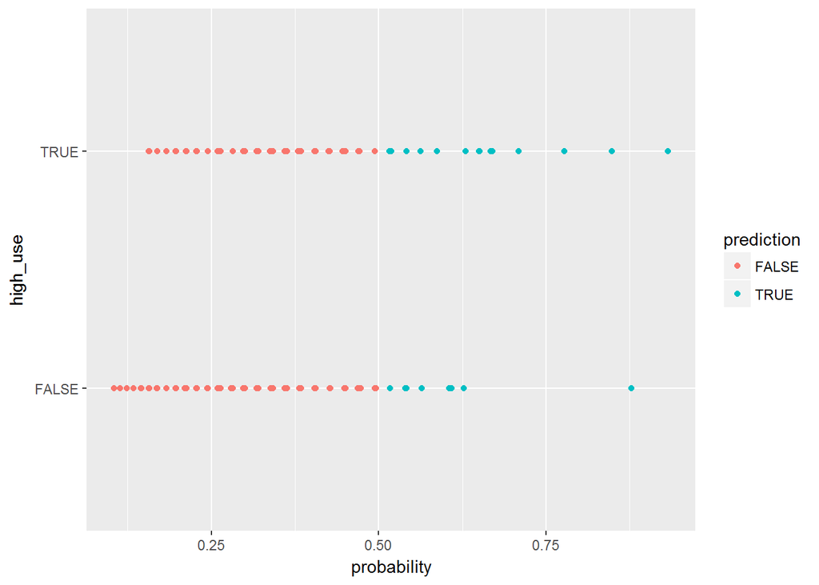

```
##         prediction
## high_use      FALSE       TRUE        Sum
##    FALSE 0.67539267 0.02617801 0.70157068
##    TRUE  0.25130890 0.04712042 0.29842932
##    Sum   0.92670157 0.07329843 1.00000000
```

```
## [1] 0.2774869
```